# Survival Analysis - BMT Data

Dhiraj Khanna

23 September 2016

## Introduction

Not knowing the time of death of individuals leads to censoring. This situation arises if some individuals manage to outlive the experiment or they leave the experiment before they die. The last follow up date might be available for such individuals but there exists no way of determining their age at death.

Another reason for censoring is loss of individuals to the study. They may be killed in accidents, change their location, etc. Hence the survival data is a mixture of times at death and times after which we have no more information on the individual. The standard practice in such cases is to establish a *censoring indicator* which distinguishes between the two types of numbers. This indicator/vector takes on the value 1 in case date of death is available and a value of 0 in case the time value is the last time the individual was sighted alive.

## BMT Data

The `R` statistical programming language provides packages to analyze survival data. In particular, the `survival` and `KMsurv` packages contain useful functions for this sort of analysis.

The dataset comprises of 148 observations of 42 different variables. The variables of interest are `TypeOfMM`, `Transplant.Date`, `C.Status` (Current Status), `Death.date` and `LFU.Date`.

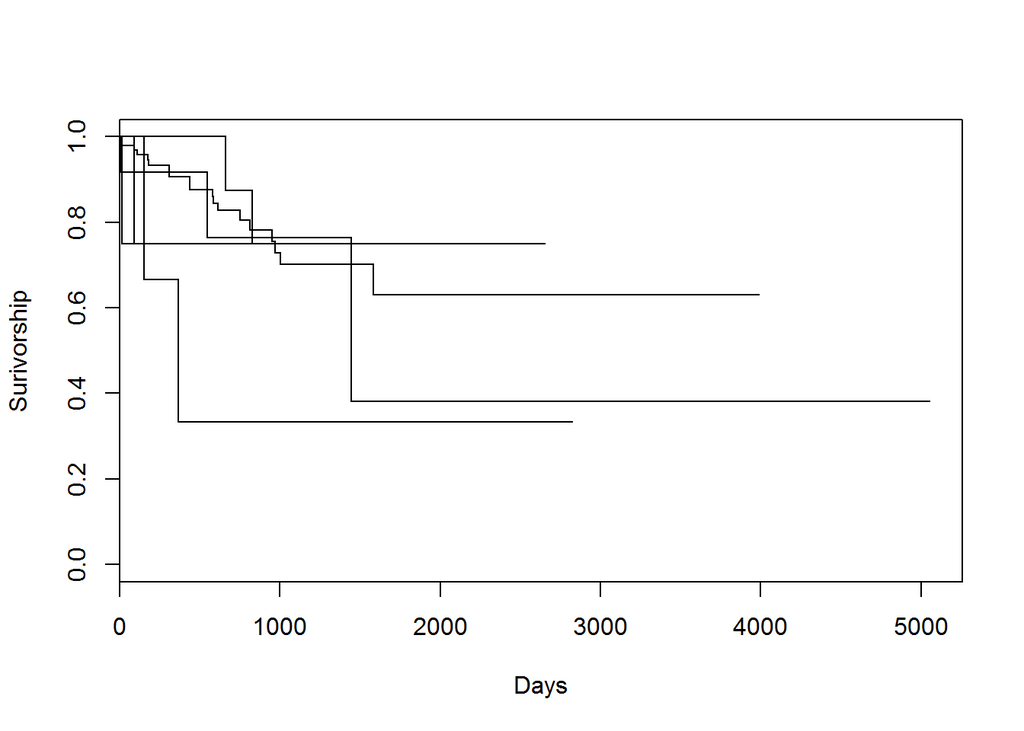

```r
library(dplyr)
library(ggplot2)
library(survival)
library(lubridate)
library(tidyr)
library(broom)

#Read in the data
BMT <- read.csv("BMT.csv")

#Select variables of interest
BMT1 <- select(BMT, TypeOfMM, Transplant.Date, C.Status,Death.date, LFU.Date)
BMT1$Transplant.Date <- dmy(BMT1$Transplant.Date)
BMT1$LFU.Date <- dmy(BMT1$LFU.Date)
BMT1$Death.date <- dmy(BMT1$Death.date)

#Create censoring indicator variable
cenin <- rep(1, nrow(BMT1))
for (i in 1:nrow(BMT1)) ifelse(BMT1$C.Status[i]!='Dead',cenin[i] <- 0,cenin[i] <- 1)

#Replace 'NA' death dates with LFU dates
index <- which(is.na(BMT1$Death.date))
BMT1$Death.date[index] <- BMT1$LFU.Date[index]

#Find time difference
BMT1 <- mutate(BMT1, TD=as.numeric(Death.date-Transplant.Date))
surv_data <- cbind(BMT1,cenin)


#Remove missing values
surv_data_final <- na.omit(surv_data)
surv_data_final$TypeOfMM[126] <- "IgG"
surv_data_final$TypeOfMM <- factor(surv_data_final$TypeOfMM)
# surv_data_final$death <- as.numeric(surv_data_final$death)
# surv_data_final$status <- as.numeric(surv_data_final$status)
attach(surv_data)
plot(survfit(Surv(TD,cenin)~TypeOfMM),ylab="Surivorship",xlab="Days")
```

```r
#model
model <- survfit(Surv(TD,cenin)~TypeOfMM)
summary(model)
```

```
## Call: survfit(formula = Surv(TD, cenin) ~ TypeOfMM)
##
## 8 observations deleted due to missingness
##                 TypeOfMM=
##      time n.risk n.event survival std.err lower 95% CI upper 95% CI
##
##                 TypeOfMM=IgA
##  time n.risk n.event survival std.err lower 95% CI upper 95% CI
##    11     12       1    0.917  0.0798       0.7729            1
##   545      6       1    0.764  0.1545       0.5139            1
##  1447      2       1    0.382  0.2809       0.0904            1
##
##                 TypeOfMM=IgD
##         time       n.risk      n.event     survival      std.err
##       89.000        4.000        1.000        0.750        0.217
## lower 95% CI upper 95% CI
##        0.426        1.000
##
##                 TypeOfMM=IgG
##  time n.risk n.event survival std.err lower 95% CI upper 95% CI
##     9    100       1    0.990 0.00995        0.971        1.000
##    16     99       1    0.980 0.01400        0.953        1.000
##    92     88       1    0.969 0.01773        0.935        1.000
##   112     86       1    0.958 0.02079        0.918        0.999
##   174     79       1    0.945 0.02380        0.900        0.993
##   181     76       1    0.933 0.02654        0.882        0.987
##   309     69       1    0.920 0.02940        0.864        0.979
##   311     68       1    0.906 0.03193        0.846        0.971
##   438     61       1    0.891 0.03469        0.826        0.962
##   439     60       1    0.876 0.03715        0.806        0.952
##   580     54       1    0.860 0.03985        0.785        0.942
##   585     53       1    0.844 0.04227        0.765        0.931
##   614     51       1    0.827 0.04457        0.744        0.919
##   750     36       1    0.804 0.04889        0.714        0.906
##   811     35       1    0.781 0.05262        0.685        0.892
##   949     30       1    0.755 0.05695        0.652        0.876
##   969     29       1    0.729 0.06065        0.620        0.858
##  1004     26       1    0.701 0.06448        0.586        0.840
##  1584     10       1    0.631 0.08827        0.480        0.830
##
##                 TypeOfMM=IgM
##         time       n.risk      n.event     survival      std.err
##       15.000        4.000        1.000        0.750        0.217
## lower 95% CI upper 95% CI
##        0.426        1.000
##
##                 TypeOfMM=LC
##  time n.risk n.event survival std.err lower 95% CI upper 95% CI
##   663      8       1    0.875   0.117        0.673            1
##   827      7       1    0.750   0.153        0.503            1
##
##                 TypeOfMM=NSM
##  time n.risk n.event survival std.err lower 95% CI upper 95% CI
##   154      3       1    0.667   0.272       0.2995            1
##   365      2       1    0.333   0.272       0.0673            1
```

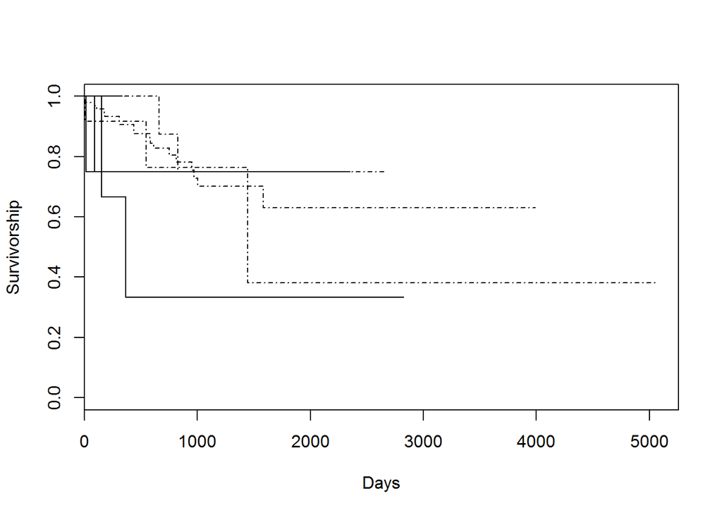

```r
plot(model,lty=c(1,4),ylab="Survivorship",xlab="Days")
```

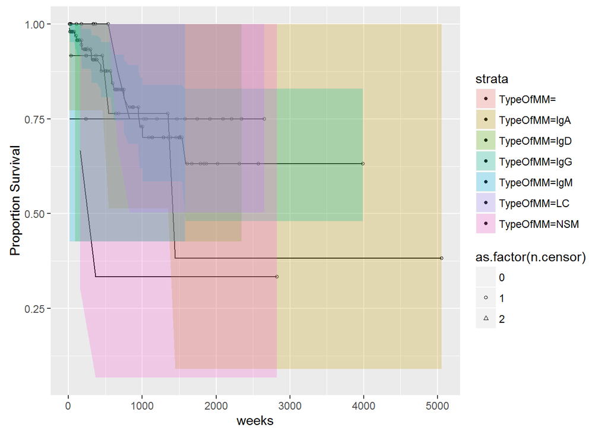

```r
# ggplot2 version of the plot
tongue_tidy = tidy(survfit(Surv(TD,cenin)~TypeOfMM))
mx = max(tongue_tidy$n.censor)
ggplot(tongue_tidy, aes(time, estimate, fill = strata)) +
  geom_line() +
  geom_point(aes(shape = as.factor(n.censor)), size = 1) +
  scale_shape_manual(values=c(NA, 1:mx))+
  geom_ribbon(aes(ymin=conf.low, ymax=conf.high), alpha=.25) +
  xlab("weeks") +
  ylab("Proportion Survival")
```